# Lecture 7：商品設計とコンジョイント分析

計量経済学II

Kei Ikegami

## 今日の問い

既存商品の購買履歴にない比較を、どう作るか。

価格と機能を変えた仮想の商品を提示し、選んでもらう。

平均効果から、個人の好みと商品設計へ進む。

## まずQuiz 7

第6回の復習

## 第6回とのつながり

購買履歴：同じ人の複数の選択から好みを学ぶ。

コンジョイント：好みを測るための選択課題を設計する。

どちらも、一人の情報が少ないという問題を持つ。

## Revealed preferenceとstated preference

|  | RP | SP |
| --- | --- | --- |
| 行動 | 実際の購入 | 仮想商品の選択 |
| 価格・機能 | 市場で観測 | 調査で割り付け |
| 注意 | 価格内生性など | 実際の購入との違い |

## ワイヤレスイヤホン

| 属性 | 水準 |
| --- | --- |
| 価格 | 8、12、16千円 |
| バッテリー | 6、12時間 |
| ノイキャン | なし、あり |
| ブランド | 新興、大手 |

A、B、どちらも買わない、から選ぶ。

## 選択課題の例

| profile | price | battery_hours | nc | major_brand |
| --- | --- | --- | --- | --- |
| A | 16 | 12 | 0 | 0 |
| B | 8 | 12 | 0 | 0 |

## 同じデータから異なる量を推定する

- AMCE：属性による選択確率の平均変化。
- 効用係数：選択モデルでの属性評価。
- WTP：属性係数と価格係数の比。
- 個人予測：本人の係数の分布を使う。

これらを同じ数値として読まない。

## AMCE

$$E_{i,W}[Y_{iA}(1,W)-Y_{iA}(0,W)]$$

ノイキャンを付けたときの変化を、他の属性・相手の商品・回答者について平均する。

平均に使うのは、調査で設定した割付分布。

## ランダム化でできること

提示価格は、企業が商品人気を見越して決めた価格とは異なる。

独立した属性割付のもとで、水準ダミーのOLSからAMCEを推定できる。

実市場への予測には別途検証が必要。

## データ生成のモデル

$$v_{ijt}=.5\,battery12_{ijt}+.8\,nc_{ijt}+.3\,brand_{ijt}-\alpha_i p_{ijt}$$

$$\alpha_i=e^{\theta_i},\quad\theta_i\sim N(\mu,.6^2)$$

$E[\alpha_i]=.12$ になるよう $\mu$ を設定。

## 何を簡単にしているか

属性係数は共通、価格係数だけが人によって違う。

同じ人の係数は8問を通じて固定。

300人×8問で分析し、別の8問は第9回の評価用に保留。

## 価格感応度の分布

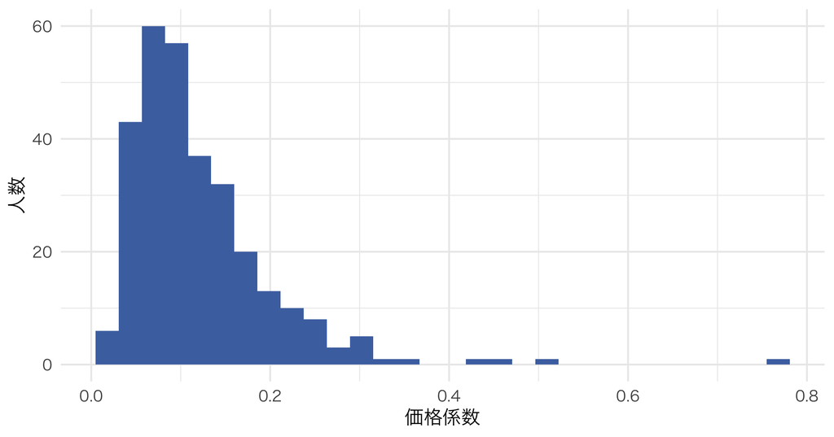

## 回答を2行にする

Aを選ぶ：$(Y_A,Y_B)=(1,0)$。

Bを選ぶ：$(0,1)$。

買わない：$(0,0)$。

outsideの回答も落とさない。

## AMCEを回収できたか

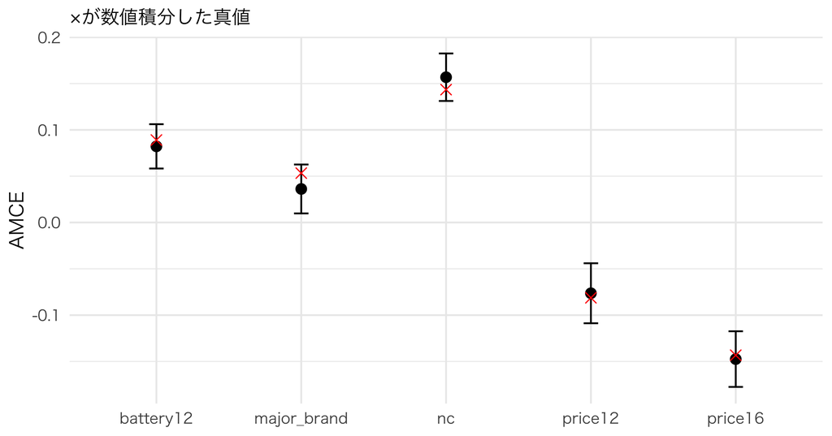

## 4,800行は独立ではない

300人×8問×2商品。

同じ人の回答は同じ係数を共有し、同じ問のAとBも依存する。

標準誤差を回答者単位で計算する。

## 買わない回答を落とすと

購入するかどうか自体が属性の影響を受ける。

購入した問だけを残すと、割付後の結果で標本を選ぶことになる。

最初からA/Bの強制選択を求めた調査とも異なる。

## 同質logitを当てはめる

今回の真のデータには係数の異質性がある。

$$E_\theta[P_j(\theta)]\ne P_j(E[\theta])$$

同質logitはworking modelとしての近似であり、係数平均の推定ではない。

## WTPを定義する

$$\mathrm{WTP}_i=\beta_i/\alpha_i$$

機能による効用増加を打ち消す価格上昇分。

価格単位が千円なら、WTPも千円。

## 平均する順序で違う

$$E[\beta_i/\alpha_i]\ne E[\beta_i]/E[\alpha_i]$$

| quantity | thousand_yen |
| --- | --- |
| 個人WTPの平均（真値） | 9.56 |
| 個人WTPの中央値（真値） | 7.98 |
| 平均係数の比（真値） | 6.67 |
| 同質logitで推定した比 | 7.91 |

## 個人WTPには幅がある

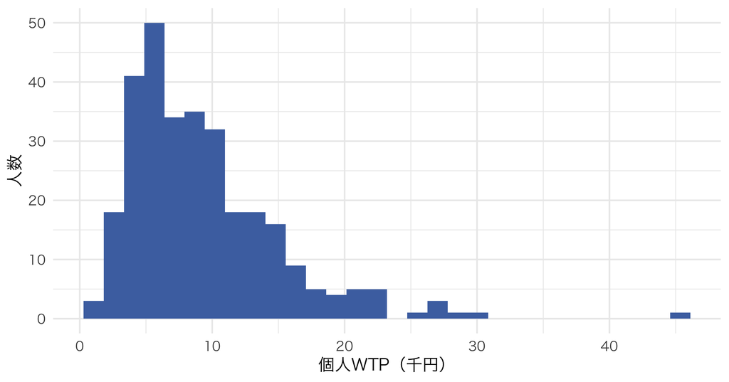

## WTPの推定誤差

$$\nabla g=(1/\alpha,-\beta/\alpha^2)'$$

$$\operatorname{SE}(\hat g)\simeq\sqrt{\nabla g'\widehat V\nabla g}$$

2つの係数の分散だけでなく、共分散も使う。

## デルタ法を使うとき

- 何のWTPを推定しているかを先に決める。
- working modelの区間は、そのモデルの比の区間。
- 価格係数が0に近いと比は不安定。

デルタ法が異質性の誤指定を解消するわけではない。

## 商品設計では特定の組合せを比べる

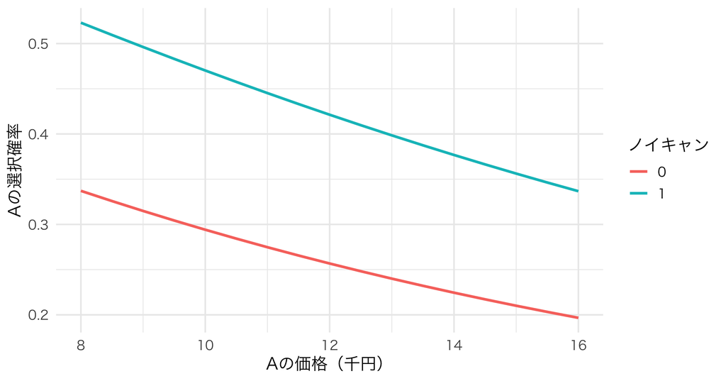

## 標準版と上位版

価格に敏感な人と、機能のためなら高い価格を払う人。

標準版を残すと購入を保てるが、上位版から移る人もいる。

異質性は、誰に勧めるかだけでなく商品群の設計にも関係する。

## 調査回答と実行動

Hainmueller, Hangartner, and Yamamoto (2015) は、スイスの帰化投票と調査を比較。

属性効果の差はpaired conjointで平均2ポイント。一方、拒否率の水準は調査予測21%、実際37%。

効果の比較と、水準の予測を区別する。

[一次論文](https://doi.org/10.1073/pnas.1416587112)

## 8問から個人係数を知りたい

$$L_i(\theta_i)=\prod_{t=1}^8P_{iy_{it}t}(e^{\theta_i})$$

本人の尤度と、母集団の分布を組み合わせる。

短い購買履歴のときと同じ情報共有の問題。

## 次回と第9回

第8回：事前分布・尤度・事後分布、partial pooling。

第9回：同じCBCデータで階層ベイズlogitを推定。

第9回は属性係数を既知に固定し、個人価格係数と母集団分布を推定する。

## まとめ

- CBCは比較を作るための選択実験。
- AMCE、効用係数、WTPは異なる量。
- 異質性は商品設計にも必要。
- 個人の少ない回答を、集団の情報と組み合わせる。

講義ノート / 課題7 / Playground